# 826 Homework 1

Data

Let’s look at the data in a couple of ways to make sure everything checks out.

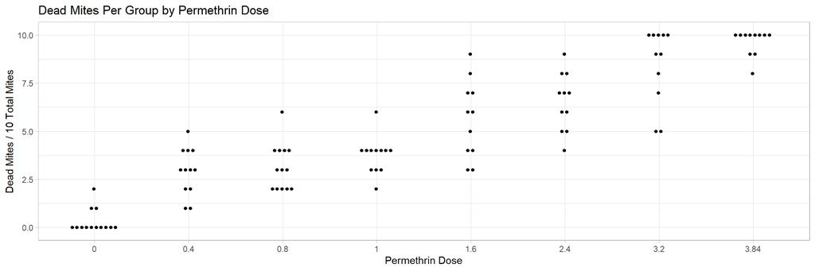

```r
ggplot(mites, aes(x = factor(dose), y=num_dead)) + geom_dotplot(binaxis='y', stackdir='center',
               stackratio=1.5, dotsize=0.5) + ggtitle("Dead Mites Per Group by Permethrin Dose") + labs(y = "Dead Mites / 10 Total Mites", x = "Permethrin Dose") + theme_light()
```

Let’s look at the number of experiments that were done at each doseage. It appears alternately 13 and 12 groups of 10 mites were tested for the lower doseages, and 11 groups for the higher doseages.

```r
num_experiments_df <- mites %>% group_by(dose) %>% summarize(number_of_experiments = n())
num_experiments <- as.vector(num_experiments_df$number_of_experiments)
print(num_experiments_df)
```

```
## # A tibble: 8 x 2
##   dose  number_of_experiments
##   <fct>                 <int>
## 1 0                        13
## 2 0.4                      12
## 3 0.8                      13
## 4 1                        12
## 5 1.6                      11
## 6 2.4                      11
## 7 3.2                      11
## 8 3.84                     11
```

‘Hypothesis that the mites are dying independently at a constant probability’ suggests a null model with a binomial distribution with a different p for every level of dose.

X = # of dead mites dose = Level of dose
$$X|dose \sim BN(10,p_{dose})$$

Estimate p for each doseage level

```r
dose_means <- mites %>% group_by(dose) %>% summarize(p_dose = weighted.mean(num_dead/num_mites,num_mites))
print(dose_means)
```

```
## # A tibble: 8 x 2
##   dose  p_dose
##   <fct>  <dbl>
## 1 0     0.0308
## 2 0.4   0.292
## 3 0.8   0.315
## 4 1     0.375
## 5 1.6   0.564
## 6 2.4   0.655
## 7 3.2   0.845
## 8 3.84  0.964
```

```r
dose_vec <- as.vector(dose_means$dose)
p_dose <- as.vector(dose_means$p_dose)
num_dose_level <- length(dose_vec)
```

Run a goodness of fit test on each doseage level using the p_dose calculated from the observed data

```r
chi_sq = 0
df = 0
for(d in 1:num_dose_level){
  loop_df <- mites %>% filter(dose == dose_vec[d])
  counts <- table(factor(loop_df$num_dead, levels = 0:10))
  labs <- as.numeric(names(counts))

  expected_counts <- c()

  for(l in labs){
    expected_counts <- c(expected_counts, dbinom(l, size=10, prob=p_dose[d])*num_experiments[d])
  }

  df = df + length(counts)
  chi_sq = chi_sq + sum((counts-expected_counts)^2/expected_counts)
}

print(df)
```

```
## [1] 88
```

```r
print(qchisq(.95, df=df-1))
```

```
## [1] 109.7733
```

```r
print(chi_sq)
```

```
## [1] 66.48257
```

Let’s define a model and simulate data that is identical in dimension to our given data. Then we can see how reasonable the observed data is in relation to the simulated data.

```r
m = 10000

sim_mites_matrix <- function(d, num_experiments, size, p_dose) {

  # Generate a dataframe of simulated data with the same dimension as the mites dataframe
  sim_dead <- rbinom(num_experiments[d], size, p_dose[d])

  loop_df <- as.matrix(cbind(dose = rep(as.numeric(dose_vec[d])), num_mites=rep(size), num_dead = sim_dead))
}

sim_mites_data <- function(i, num_experiments, size, p_dose, num_dose_level){

  sim_df <- data.frame(do.call(rbind, lapply(1:num_dose_level, sim_mites_matrix, num_experiments, 10, p_dose)))

  return(sim_df)

}

sim_data <- lapply(1:m, sim_mites_data, num_experiments = num_experiments, size = 10, p_dose = p_dose, num_dose_level = num_dose_level)
```

```r
two_way_anova <- function(sim_data, obs_data){
  sim_data$dose <- factor(sim_data$dose)
  sim_data$observed_data <- 0
  df <- rbind(sim_data, obs_data)
  df$observed_data <- factor(df$observed_data)

  anova_output <- aov(num_dead ~ dose + observed_data, data = df)
  anova_summary <- summary(anova_output)
  f_value <- anova_summary[[1]]$`F value`[2]
  p_value <- anova_summary[[1]]$`Pr(>F)`[2]

  out_stats <- as.matrix(cbind(f_value, p_value))
  return(out_stats)
}

sim_metrics <- data.frame(do.call(rbind, lapply(sim_data, two_way_anova, obs_data = mites)))
```

```r
nrow(sim_metrics %>% filter(p_value < 0.05))/m
```

```
## [1] 0.0048
```

Visualize the distribution of p-values

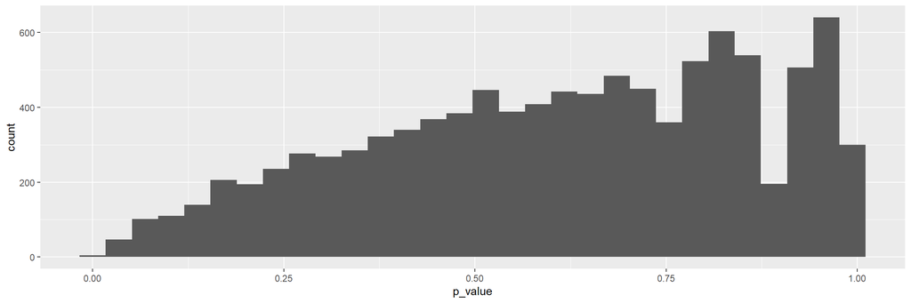

```r
ggplot(sim_metrics, aes(x=p_value)) + geom_histogram()
```

Now let’s do this analysis but with a twist – let’s see if the variance of the observed data is a reasonable reflection of a binomial distribution.

```r
two_way_anova_levene <- function(sim_data, obs_data){
  sim_data$dose <- factor(sim_data$dose)
  sim_data$observed_data <- 0
  df <- rbind(sim_data, obs_data)
  df$observed_data <- factor(df$observed_data)
  df <- df %>% group_by(dose, observed_data) %>% mutate(abs_diff = abs(num_dead - mean(num_dead)))

  anova_output <- aov(abs_diff ~ dose + observed_data, data = df)
  anova_summary <- summary(anova_output)
  f_value <- anova_summary[[1]]$`F value`[2]
  p_value <- anova_summary[[1]]$`Pr(>F)`[2]

  out_stats <- as.matrix(cbind(f_value, p_value))
  return(out_stats)
}

sim_metrics <- data.frame(do.call(rbind, lapply(sim_data, two_way_anova_levene, obs_data = mites)))
```

```r
nrow(sim_metrics %>% filter(p_value < 0.05))/m
```

```
## [1] 0.0335
```

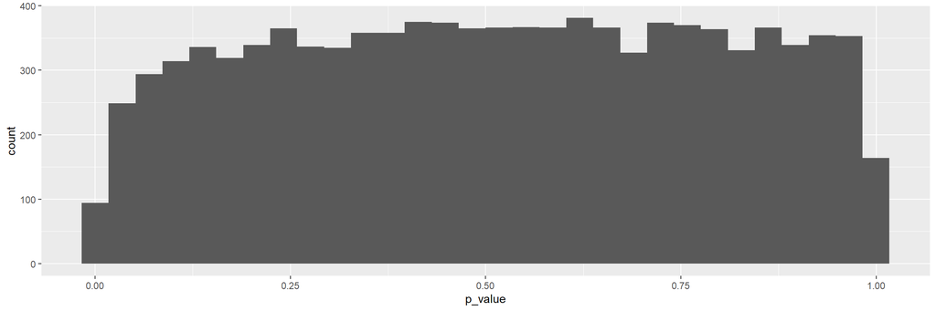

```r
ggplot(sim_metrics, aes(x=p_value)) + geom_histogram()
```

2. Make the binomial assumption for mites at each dose and pool the data across groups. Then fit a dose-response curve of a standard type (e.g., probit, logit, complementary log-log, etc.), justifying your choice. That is, fit a generalized linear model (with glm in R, or with the python module statsmodels).

```r
# Create full dataset by_miteA with row for each mite from summary dataset mites
by_miteA <- data.frame(mite_id=integer(),
                 dose=double(),
                 death_status=logical(),
                 stringsAsFactors=FALSE)
mite_id_ticker = 1
for (row in 1:nrow(mites)) {

    # Extract information in each row
    num_mites <- mites[row, "num_mites"]
    num_dead  <- mites[row, "num_dead"]
    dose <- mites[row, "dose"]

    # Create vectors of data based on the number of mites per experiment
    dead_vec <- !logical(length = num_dead)
    alive_vec <- logical(length = num_mites - num_dead)
    death_status_vec <- c(dead_vec, alive_vec)
    dose_vec <- rep(dose, num_mites)
    ids <- seq(from = mite_id_ticker, to = mite_id_ticker + num_mites - 1)

    # Create dataframe from vectors
    loop_df <- data.frame(mite_id = ids, dose = dose_vec, death_status = death_status_vec)

    # Append at each iteration to dataframe by_miteA
    by_miteA <- rbind(by_miteA, loop_df)

    mite_id_ticker <- mite_id_ticker + num_mites
}

by_miteA$dose <- as.numeric(by_miteA$dose)
```

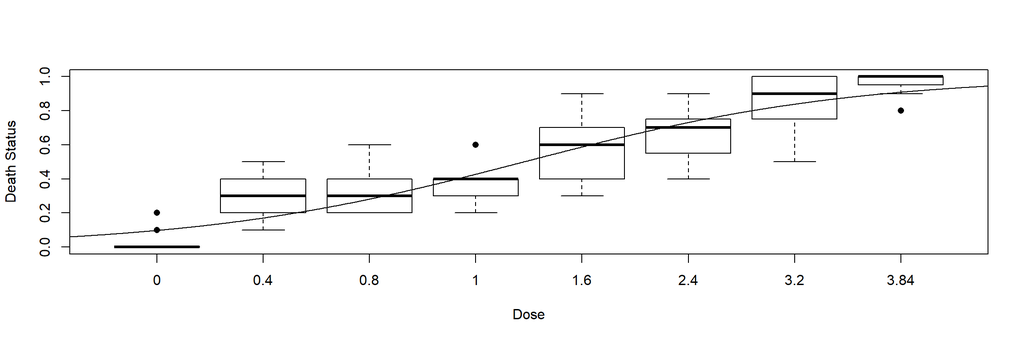

```r
miteA_logit <- glm(death_status ~ dose, data = by_miteA, family = binomial(link = "logit"))

pred_x <- seq(0, 10, 0.01)
pred_y <- predict(miteA_logit, list(dose = as.numeric(pred_x)), type="response")

plot(mites$dose, mites$num_dead/mites$num_mites, pch = 16, xlab = "Dose", ylab = "Death Status")
lines(pred_x, pred_y)
```

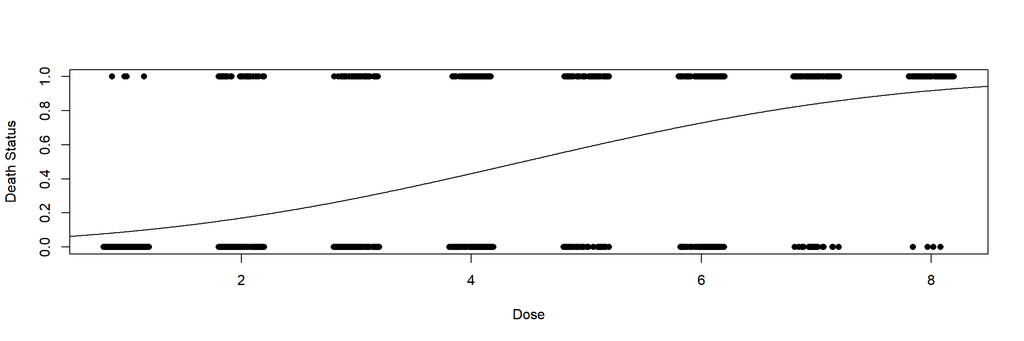

```r
miteA_probit <- glm(death_status ~ dose, data = by_miteA, family = binomial(link = "probit"))

pred_x <- seq(0, 10, 0.01)
pred_y <- predict(miteA_probit, list(dose = pred_x), type="response")

plot(jitter(by_miteA$dose,1), by_miteA$death_status, pch = 16, xlab = "Dose", ylab = "Death Status")
lines(pred_x, pred_y)
```

3. Estimate the LD50 (the dose at which the probability of death is 50%) and its standard error (SE).
4. How might you need to modify your analyses in (b) and (c) in light of your conclusions in (a)?
5. Repeat (a)-(d) for data on a second strain of mites, in hw1_mitesB.txt.